# A Bit About Me

Shravan Sundar Ravi

2024-12-08

## About Me

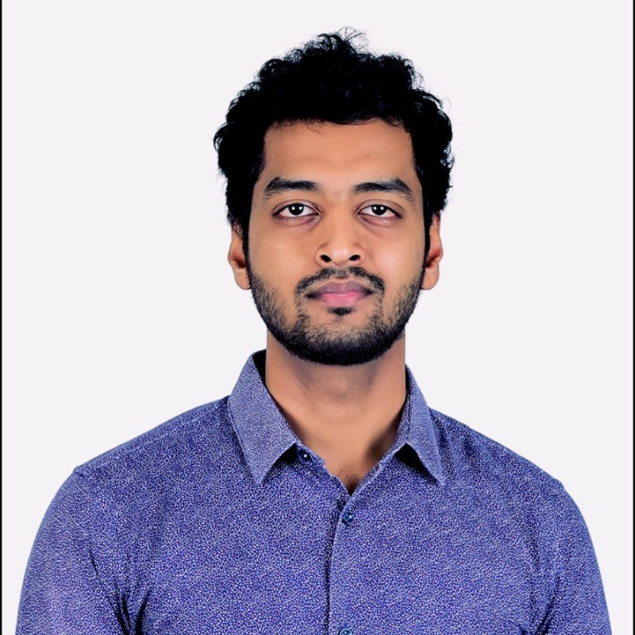

I am Shravan Sundar Ravi, a passionate data professional with a Master’s degree in Data Analytics from the University of Massachusetts Amherst. With over two years of experience in data analysis and a strong foundation in predictive modeling, I specialize in deriving actionable insights from complex datasets. My professional journey includes impactful roles at KOCH Industries, where I contributed to data solutions, enhanced system efficiency, and automated processes as a Software Developer Intern and Programmer Analyst. I’ve successfully applied Agile methodologies, including Kanban boards, to streamline workflows and foster collaboration in cross-functional teams.

My academic and professional pursuits have honed my expertise in customer analytics, with projects such as customer churn prediction and customer lifetime value modeling. I have also built an ad click-through rate optimization pipeline using data from platforms like Google Analytics, demonstrating my ability to merge data engineering with business strategy. Currently, I am deepening my technical skills by developing analytic structures within DBT pipelines and creating data visualization scripts.

Beyond technical expertise, I bring a collaborative and innovative mindset to every project, whether it’s building machine learning models, optimizing data pipelines, or crafting compelling visual narratives. I’m actively seeking roles in Data Science, Data Engineering, or Machine Learning Engineering that align with my goal to drive meaningful impact through data-driven decisions. Balancing work with personal growth, I also serve as a part-time worker at the UMass Dining Commons, showcasing my dedication and ability to manage diverse responsibilities effectively.

you can access my cv here at : https://github.com/Shravan-Sundar14/DACSS-604-Final-Project/blob/main/CV.pdf